# RPointCloud: Regulatory T Cells

Kevin R. Coombes

# Introduction

We want to illustrate the `RPointCloud` package (Version 0.9.2) with a single-cell mass cytometry data set. Not surprisingly, we start by loading the package.

```r
library(RPointCloud)
```

We also load a lot of useful packages (some of which will eventually get incorporated into the package requirements).

```r
library(TDA)
```

```r
library(Polychrome)
data(Dark24)
data(Light24)
library(Mercator)
library(igraph)
library(ClassDiscovery)
library(PCDimension)
library("ape")
```

Now we fetch the sample data set that is included with the package.

```r
nenv <- new.env()
data("treg", envir = nenv)
ls(nenv)
```

```
## [1] "rip"  "tmat" "treg"
```

```r
attach(nenv)
```

# TDA Built-in Visualizations of the Rips Diagram

Here are some plots of the `TDA` results using tools from the original package. (I am not sure what any of these are really good for.)

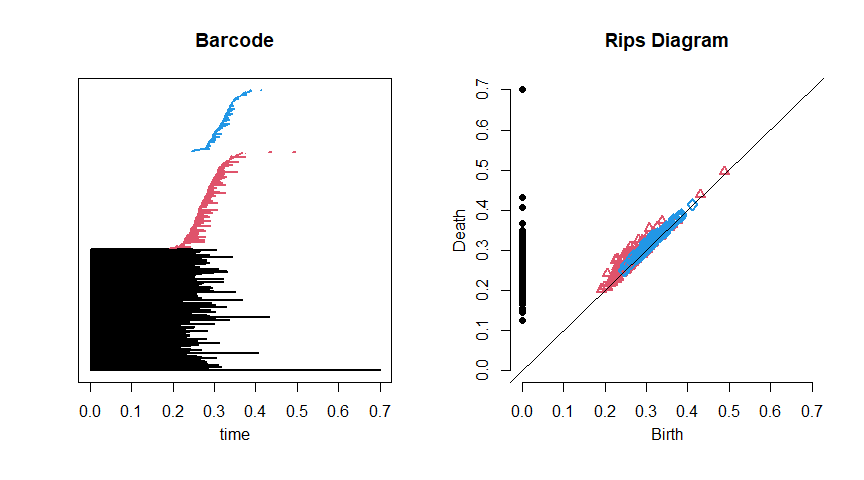

Figure 1 : The Rips barcode diagram from TDA.

```r
diag <- rip[["diagram"]]
opar <- par(mfrow = c(1,2))
plot(diag, barcode = TRUE, main = "Barcode")
plot(diag, main = "Rips Diagram")
```

```r
par(opar)
rm(opar)
```

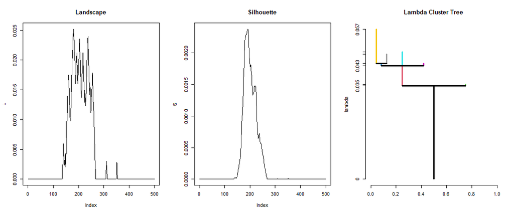

Figure 2 : Landscape, silhouette, and lambda-cluster plots of the Rips diagram, from TDA.

```r
L <- TDA::landscape(diag, KK = 1)
S <- TDA::silhouette(diag)
crt <- TDA::clusterTree(as.matrix(tmat), k = 5, dist = "arbitrary")

opar <- par(mfrow = c(1, 3))
plot(L, type = "l", main = "Landscape")
plot(S, type = "l", main = "Silhouette")
plot(crt, type = "lambda",main = "Lambda Cluster Tree")
```

```r
par(opar)
rm(L, S, opar)
```

# Mercator Visualizations of the Underlying Data and Distance Matrix

```r
M <- Mercator(tmat, metric ="pearson", method = "mds", K = 8)
M <- addVisualization(M, "hclust")
M <- addVisualization(M, "tsne")
M <- addVisualization(M, "umap")
M <- addVisualization(M, "som")
M@palette <- Light24
set.seed(72345)
clue <- kmeans(t(treg), centers = 8, iter.max = 100, nstart = 20)
M <- setClusters(M, clue$cluster)
```

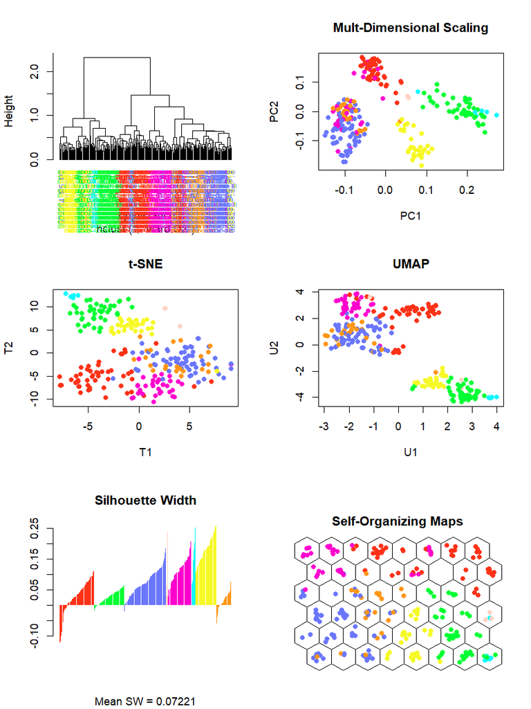

Figure 3 : Mercator Visualizations of the distance matrix.

```r
opar <- par(mfrow = c(3,2), cex = 1.1)
plot(M, view = "hclust")
plot(M, view = "mds", main = "Mult-Dimensional Scaling")
plot(M, view = "tsne", main = "t-SNE")
plot(M, view = "umap", main = "UMAP")
barplot(M, main = "Silhouette Width")
plot(M, view = "som", main = "Self-Organizing Maps")
```

```r
par(opar)
rm(opar)
```

# Dimension Zero

Here is a picture of the “zero-cycle” data, which can also be used ultimately to cluster the points (where each point is a patient). The connected lines are similar to a single-linkage clustering structure, showing when individual points are merged together as the TDA parameter increases.

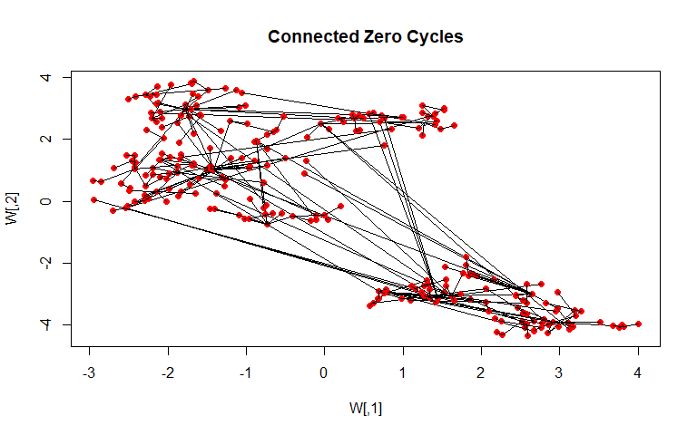

Figure 4 : Hierarchical connections between zero cycles.

```r
nzero <- sum(diag[, "dimension"] == 0)
cycles <- rip[["cycleLocation"]][2:nzero]
W <- M@view[["umap"]]$layout
plot(W, main = "Connected Zero Cycles")
for (cyc in cycles) {
  points(W[cyc[1], , drop = FALSE], pch = 16,col = "red")
  X <- c(W[cyc[1], 1], W[cyc[2],1])
  Y <- c(W[cyc[1], 2], W[cyc[2],2])
  lines(X, Y)
}
```

# Using iGraph

We can convert the 0-dimensional cycle structure into a dendrogram, by first passing them through the `igraph` package. We start by putting all the zero-cycle data together, which can be viewed as an “edge-list” from the `igraph` perspective.

```r
edges <- t(do.call(cbind, cycles)) # this creates an "edgelist"
G <- graph_from_edgelist(edges)
G <- set_vertex_attr(G, "label", value = attr(tmat, "Labels"))
```

Note that we attached the sample names to the graph, obtaining them from the daisy distance matrix. Now we use two different algorithms to decide how to layout the graph.

```r
set.seed(2734)
Lt <- layout_as_tree(G)
L <- layout_with_fr(G)
```

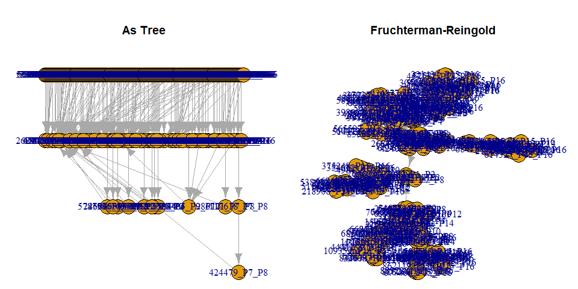

Figure 5 : Two igraph depictions of the zero cycle structure.

```r
opar <- par(mfrow = c(1,2), mai = c(0.01, 0.01, 1.02, 0.01))
plot(G, layout = Lt, main = "As Tree")
plot(G, layout = L, main = "Fruchterman-Reingold")
```

```r
par(opar)
```

Note that the Fruchterman-Reingold layout gives the most informative structure.

## Community Structure

There are a variety of community-finding algorithms that we can apply. (Communities in graph theory are similar to clusters in other machine learning areas of study.) “Edge-betweenness” seems to work best.

```r
keg <- cluster_edge_betweenness(G) # 19
table(membership(keg))
```

```
##
##  1  2  3  4  5  6  7  8  9 10 11 12 13 14 15 16 17 18 19
## 18 13  5 31 27 26  8 16 11  9 14  8  6  8 10  5 16 10 14
```

```r
pal <- Light24[membership(keg)]
```

```r
is.hierarchical(keg)
```

```
## [1] TRUE
```

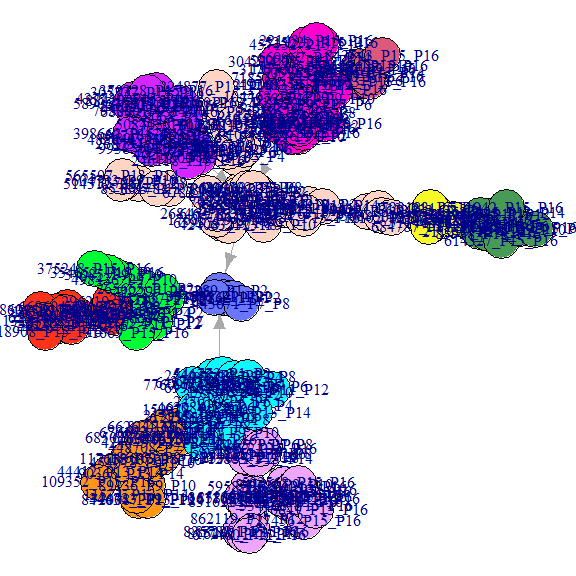

Figure 6 : Community structure, simplified.

```r
H <- as.hclust(keg)
H$labels <- vertex_attr(G, "names")
K <-  12
colset <- Light24[cutree(H, k=K)]
G2 <- set_vertex_attr(G, "color", value = colset)
e <- 0.01
opar <- par(mai = c(e, e, e, e))
plot(G2, layout = L)
```

```r
par(opar)
```

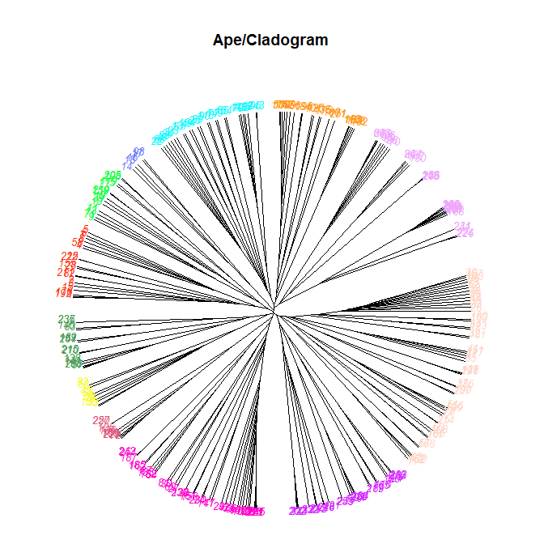

Figure 8 : Cladogram realization, from the ape package.

```r
P <- as.phylo(H)
opar <- par(mai = c(0.01, 0.01, 1.0, 0.01))
plot(P, type = "u", tip.color = colset, cex = 0.8, main = "Ape/Cladogram")
```

```r
par(opar)
rm(opar)
```

## Visualizing Features

In any of the “scatter plot views” (e.g., MDS, UMAP, t-SNE) from Mercator, we may want to overlay different colors to represent different clinical features.

```r
U <- M@view[["mds"]]
V <- M@view[["tsne"]]$Y
W <- M@view[["umap"]]$layout
```

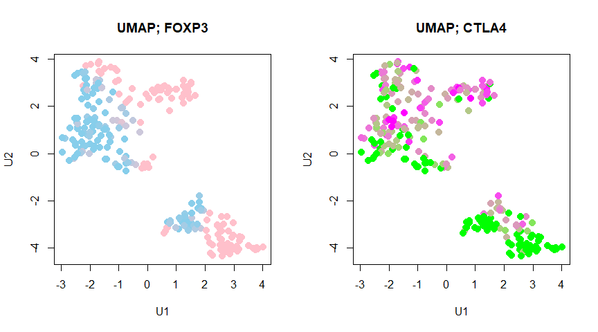

Figure 10 : UMAP visualizations with clinical features.

```r
FOXP3 <- Feature(treg["FOXP3",], "FOXP3", c("pink", "skyblue"), c("Low", "High"))
CTLA4 <- Feature(treg["CTLA4", ], "CTLA4", c("green", "magenta"), c("Low", "High"))
opar <- par(mfrow = c(1,2))
plot(W, main = "UMAP; FOXP3", xlab = "U1", ylab = "U2")
points(FOXP3, W, pch = 16, cex = 1.4)
plot(W, main = "UMAP; CTLA4", xlab = "U1", ylab = "U2")
points(CTLA4, W, pch = 16, cex = 1.4)
```

```r
par(opar)
rm(opar)
```

```r
options(oopt)
detach("nenv")
rm(nenv)
```